# COVID-19_Results

Samyak Gupta

06/05/2020

## Predictions and Plots

So this little project is just for us to learn and apply the simple techniques used in statistical learning in a real time problem in the world.

Here we predict two things:

1. No. of confirmed cases for the next few days for the world.
2. No. of confirmed cases for the next few days for India.

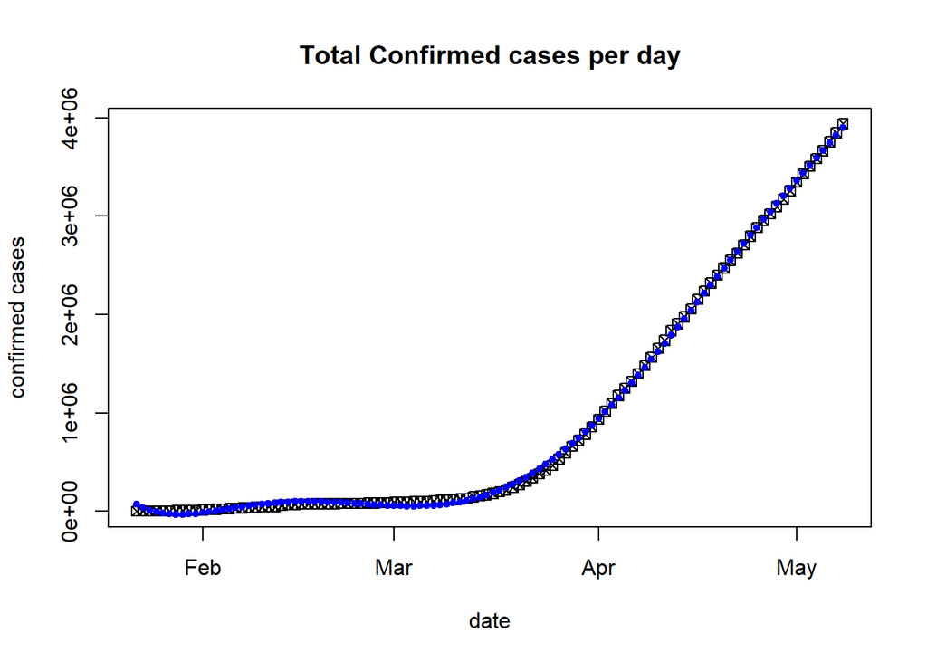

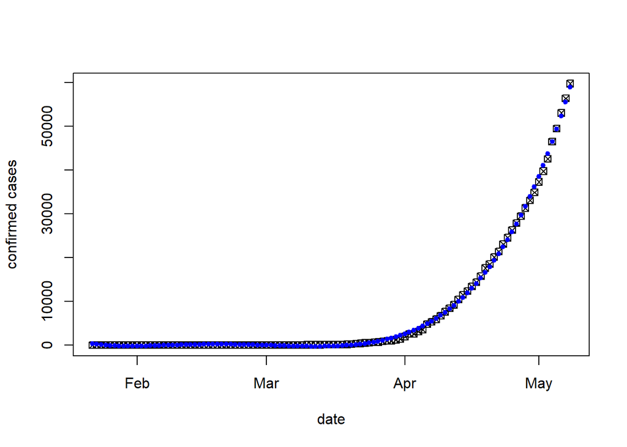

## Explaination and Infrence

Here, we use the simple linear model and gave it a polynomial argument to create the simple blue line graph shown above, the model in turn predicts the near date event and as it is obvious from the result below the nearest future predictions are most precise out of all and the accuracy of the prediction decreases as the prediction goes further in the future.

The polynomial used was of degree six as we used the method of cross validation to determine which degree will give lowest error and less computations we concluded that degree 6 was fitting the model perfectly.However, other models were also considered for this job but none gave as much accuracy than this simple polynomial.

This is the predictions for the world

| predict_date | fit | lwr | upr |
| --- | --- | --- | --- |
| 2020-05-08 | 3900793 | 3865861 | 3935725 |
| 2020-05-09 | 3980685 | 3937057 | 4024314 |
| 2020-05-10 | 4062374 | 4008155 | 4116594 |
| 2020-05-11 | 4146349 | 4079527 | 4213171 |
| 2020-05-12 | 4233151 | 4151571 | 4314731 |
| 2020-05-13 | 4323378 | 4224713 | 4422043 |
| 2020-05-14 | 4417688 | 4299418 | 4535957 |

This is the prediction for India

| t_date | fit | lwr | upr |
| --- | --- | --- | --- |
| 2020-05-08 | 58840 | 58305 | 59375 |
| 2020-05-09 | 62313 | 61645 | 62982 |
| 2020-05-10 | 65945 | 65115 | 66776 |
| 2020-05-11 | 69743 | 68719 | 70766 |
| 2020-05-12 | 73710 | 72461 | 74960 |
| 2020-05-13 | 77855 | 76344 | 79367 |
| 2020-05-14 | 82183 | 80371 | 83995 |